# Homework 02

## Question 1: Training and test error under a fixed design

Consider a linear regression problem with $n=100$ observations and $p=20$ available covariates. Generate one matrix $\mathbf X_{\mathrm{all}}\in\mathbb R^{n\times p}$ whose entries are independent $\mathcal N(0,1)$ random variables, and then keep this realized matrix fixed. Let

$$\beta_j=0.4^{\sqrt{j}},
\qquad j=1,\ldots,p,$$

and define

$$\boldsymbol\mu=\mathbf X_{\mathrm{all}}\boldsymbol\beta.$$

Generate one training response and one independent test response from

$$\begin{aligned}
\mathbf y
&=\boldsymbol\mu+\boldsymbol\epsilon,\\
\mathbf y^*
&=\boldsymbol\mu+\boldsymbol\epsilon^*,
\end{aligned}$$

where

$$\boldsymbol\epsilon,\boldsymbol\epsilon^*
\overset{\mathrm{ind}}{\sim}
\mathcal N_n(\mathbf 0,\mathbf I_n).$$

Here $\mathbf I_n$ is the $n\times n$ identity matrix.

For $m=0,1,\ldots,p$, fit a linear model with an intercept and the first $m$ columns of $\mathbf X_{\mathrm{all}}$ using $\mathbf y$. If $\widehat{\mathbf y}_m$ is its fitted mean vector, define

$$\operatorname{MSE}_{\mathrm{train},m}
=\frac{1}{n}
\left\lVert
\mathbf y-\widehat{\mathbf y}_m
\right\rVert_2^2,$$

and

$$\operatorname{MSE}_{\mathrm{test},m}
=\frac{1}{n}
\left\lVert
\mathbf y^*-\widehat{\mathbf y}_m
\right\rVert_2^2.$$

Repeat this process independently 200 times, keeping $\mathbf X_{\mathrm{all}}$ fixed.

Use seed `43202` before generating $\mathbf X_{\mathrm{all}}$ and the response errors. R and Python use different random-number generators, so their exact numerical values need not agree.

**Show the starter code**

```
 m   Average training MSE   Average test MSE
 0                 1.3220             1.3416
 1                 1.1815             1.2208
 2                 1.1124             1.1708
 3                 1.0842             1.1577
 4                 1.0319             1.1237
 5                 0.9976             1.1107
 6                 0.9667             1.1050
 7                 0.9457             1.1027
 8                 0.9270             1.1045
 9                 0.9105             1.1153
10                 0.8960             1.1218
11                 0.8844             1.1287
12                 0.8743             1.1355
13                 0.8634             1.1436
14                 0.8531             1.1534
15                 0.8446             1.1605
16                 0.8322             1.1722
17                 0.8211             1.1836
18                 0.8112             1.1938
19                 0.8009             1.2021
20                 0.7889             1.2119
```

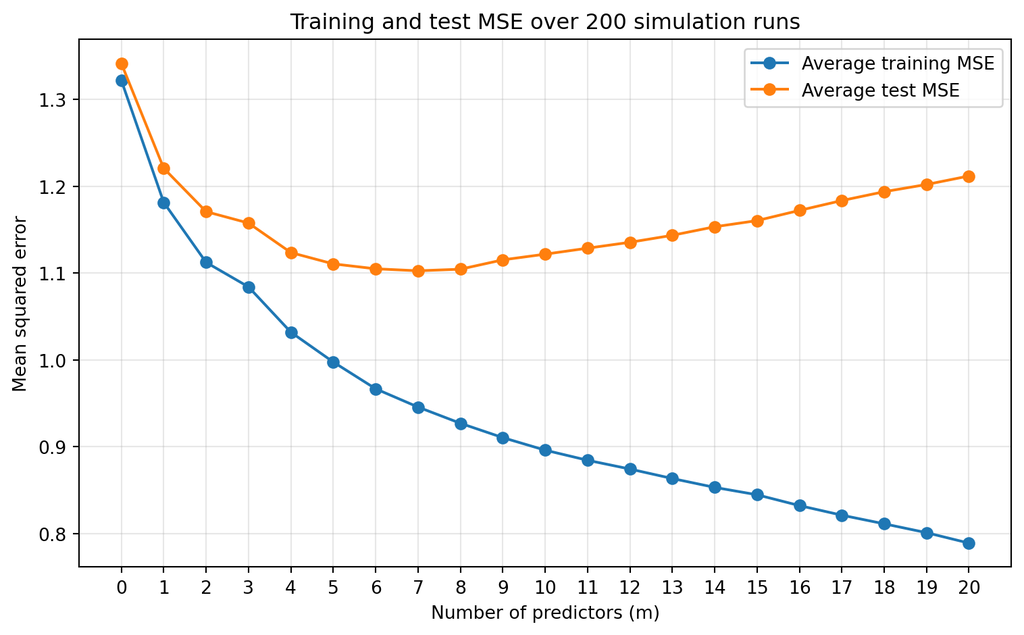

```python
import numpy as np
import matplotlib.pyplot as plt

rng = np.random.default_rng(43202)
n, p = 100, 20
n_runs = 200

# generate X_all, beta and mu
X_all = rng.normal(size=(n, p))
beta = 0.4 ** np.sqrt(np.arange(1, p + 1))
mu = X_all @ beta
X = np.column_stack((np.ones(n), X_all))


m_values = np.arange(p + 1)
train_mse = np.zeros((n_runs, p + 1))
test_mse = np.zeros((n_runs, p + 1))

for run in range(n_runs):
    y = mu + rng.normal(size=n)
    y_test = mu + rng.normal(size=n)

    for m in m_values:
        X_m = X[:, :m + 1]
        beta_hat = np.linalg.lstsq(X_m, y, rcond=None)[0]
        y_hat = X_m @ beta_hat
        train_mse[run, m] = np.mean((y - y_hat) ** 2)
        test_mse[run, m] = np.mean((y_test - y_hat) ** 2)

avg_train_mse = train_mse.mean(axis=0)
avg_test_mse = test_mse.mean(axis=0)

print(" m   Average training MSE   Average test MSE")
for m in m_values:
    print(f"{m:2d}   {avg_train_mse[m]:20.4f}   {avg_test_mse[m]:16.4f}")

plt.figure(figsize=(8, 5))
plt.plot(m_values, avg_train_mse, "o-", label="Average training MSE")
plt.plot(m_values, avg_test_mse, "o-", label="Average test MSE")
plt.xlabel("Number of predictors (m)")
plt.ylabel("Mean squared error")
plt.title("Training and test MSE over 200 simulation runs")
plt.xticks(m_values)
plt.legend()
plt.grid(alpha=0.3)
plt.tight_layout()
plt.show()
```

2. For the model containing the first $m$ predictors, write

$$\mathbf X_m
=
[\mathbf 1,\mathbf x_1,\ldots,\mathbf x_m],
\qquad
\mathbf H_m
=
\mathbf X_m
(\mathbf X_m^{\mathsf T}\mathbf X_m)^{-1}
\mathbf X_m^{\mathsf T}.$$

Here $\mathbf X_m\in\mathbb R^{n\times(m+1)}$ and $\mathbf H_m\in\mathbb R^{n\times n}$. The model has $m+1$ fitted coefficients, including the intercept. Define its **total squared approximation bias** as

$$B_m^2
=\left\lVert
(\mathbf I_n-\mathbf H_m)\boldsymbol\mu
\right\rVert_2^2.$$

Thus, $B_m^2/n$ is the mean squared approximation bias.

Calculate the two theoretical expectations

$$E\!\left(
\operatorname{MSE}_{\mathrm{train},m}
\mid \mathbf X_{\mathrm{all}}
\right)
=\frac{B_m^2}{n}+1-\frac{m+1}{n},$$

and

$$E\!\left(
\operatorname{MSE}_{\mathrm{test},m}
\mid \mathbf X_{\mathrm{all}}
\right)
=\frac{B_m^2}{n}+1+\frac{m+1}{n}.$$

Add these expectations to your plot and compare them with the simulation averages.

**Show the starter code**

```
 m   Expected training MSE   Expected test MSE
 0                  1.3078              1.3278
 1                  1.1704              1.2104
 2                  1.1024              1.1624
 3                  1.0727              1.1527
 4                  1.0216              1.1216
 5                  0.9894              1.1094
 6                  0.9627              1.1027
 7                  0.9427              1.1027
 8                  0.9254              1.1054
 9                  0.9125              1.1125
10                  0.8980              1.1180
11                  0.8856              1.1256
12                  0.8744              1.1344
13                  0.8634              1.1434
14                  0.8526              1.1526
15                  0.8419              1.1619
16                  0.8313              1.1713
17                  0.8208              1.1808
18                  0.8104              1.1904
19                  0.8002              1.2002
20                  0.7900              1.2100
```

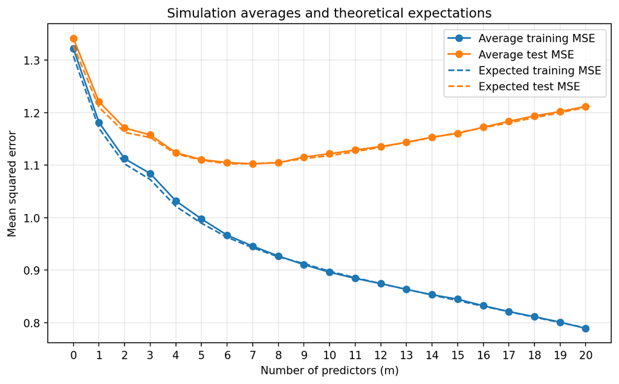

```python
bias_squared = np.zeros(p + 1)
I_n = np.eye(n)

for m in m_values:
    X_m = X[:, :m + 1]
    H_m = X_m @ np.linalg.inv(X_m.T @ X_m) @ X_m.T
    bias_squared[m] = np.linalg.norm((I_n - H_m) @ mu) ** 2

expected_train_mse = bias_squared / n + 1 - (m_values + 1) / n
expected_test_mse = bias_squared / n + 1 + (m_values + 1) / n

print(" m   Expected training MSE   Expected test MSE")
for m in m_values:
    print(f"{m:2d}   {expected_train_mse[m]:21.4f}   {expected_test_mse[m]:17.4f}")

plt.figure(figsize=(8, 5))
plt.plot(m_values, avg_train_mse, "o-", color="tab:blue",
         label="Average training MSE")
plt.plot(m_values, avg_test_mse, "o-", color="tab:orange",
         label="Average test MSE")
plt.plot(m_values, expected_train_mse, "--", color="tab:blue",
         label="Expected training MSE")
plt.plot(m_values, expected_test_mse, "--", color="tab:orange",
         label="Expected test MSE")
plt.xlabel("Number of predictors (m)")
plt.ylabel("Mean squared error")
plt.title("Simulation averages and theoretical expectations")
plt.xticks(m_values)
plt.legend()
plt.grid(alpha=0.3)
plt.tight_layout()
plt.show()
```

3. Add the test MSE curve from one simulation run to the plot. Explain why this single curve is less smooth than the average test MSE. Use the approximation-bias and estimation-variance terms in the expected test MSE to explain why training MSE cannot be used by itself to select the predictor count.

**Show the starter code**

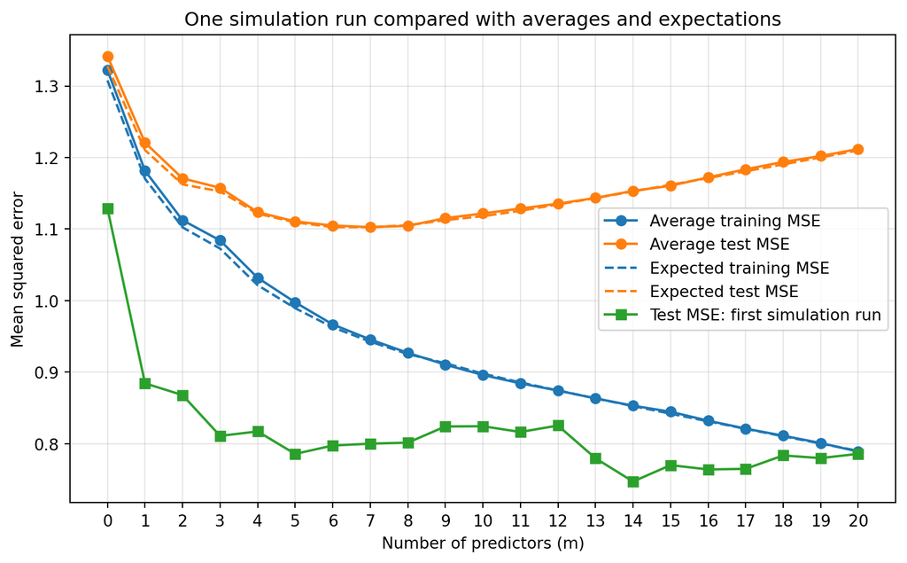

```python
single_test_mse = test_mse[0, :]

plt.figure(figsize=(8, 5))
plt.plot(m_values, avg_train_mse, "o-", color="tab:blue",
         label="Average training MSE")
plt.plot(m_values, avg_test_mse, "o-", color="tab:orange",
         label="Average test MSE")
plt.plot(m_values, expected_train_mse, "--", color="tab:blue",
         label="Expected training MSE")
plt.plot(m_values, expected_test_mse, "--", color="tab:orange",
         label="Expected test MSE")
plt.plot(m_values, single_test_mse, "s-", color="tab:green",
         label="Test MSE: first simulation run")
plt.xlabel("Number of predictors (m)")
plt.ylabel("Mean squared error")
plt.title("One simulation run compared with averages and expectations")
plt.xticks(m_values)
plt.legend()
plt.grid(alpha=0.3)
plt.tight_layout()
plt.show()
```

The average reduces the effect of random error on y_star, which leads to a smoother line for average testing MSE. Adding more predictor will reduce approximation bias and increase estimation variance, but the effect of increase estimation variance will exceed the effect of reducing bias when m is large. Therefore, prediction MSE will increase as more predictors added. However, training MSE will not increase all along. Therefore, training MSE cannot be used by itself to select the predictor count.

## Question 2: Prediction error at one target point

Let $n=100$, $p=6$, and $\sigma^2=1$. Construct the fixed covariate matrix $\mathbf X_{\mathrm{all}}\in\mathbb R^{n\times p}$ with entries

$$(\mathbf X_{\mathrm{all}})_{ij}
=\sqrt{2}\cos\left\{
\frac{\pi j(i-\tfrac12)}{n}
\right\},
\qquad
i=1,\ldots,n,
\quad
j=1,\ldots,p.$$

Its columns satisfy

$$\mathbf 1^{\mathsf T}\mathbf X_{\mathrm{all}}=\mathbf 0^{\mathsf T},
\qquad
\frac{1}{n}\mathbf X_{\mathrm{all}}^{\mathsf T}\mathbf X_{\mathrm{all}}=\mathbf I_p.$$

Here $\mathbf I_p$ is the $p\times p$ identity matrix.

The following code shows a direct construction of $\mathbf X_{\mathrm{all}}$.

**R**

```r
#| eval: false
n <- 100
p <- 6
X_all <- outer(
  1:n, 1:p,
  function(i, j) sqrt(2) * cos(pi * j * (i - 0.5) / n)
)
```

**Python**

**Show the starter code**

```python
import numpy as np

n, p = 100, 6
i = np.arange(1, n + 1)[:, None]
j = np.arange(1, p + 1)[None, :]
X_all = np.sqrt(2) * np.cos(np.pi * j * (i - 0.5) / n)
```

Keep $\mathbf X_{\mathrm{all}}$ fixed and generate one training response from

$$\mathbf y
=\mathbf X_{\mathrm{all}}\boldsymbol\beta+\boldsymbol\epsilon,
\qquad
\boldsymbol\beta
=(0.5,0.5,0.5,0.5,0.5,0.5)^{\mathsf T},$$

where

$$\boldsymbol\epsilon
\sim
\mathcal N_n(\mathbf 0,\mathbf I_n).$$

Here $\mathbf I_n$ is the $n\times n$ identity matrix.

For $m=0,\ldots,p$, fit a linear model with an intercept and the first $m$ predictors. Consider prediction of the mean response at

$$\mathbf x_0=(0,1,0,0,1,0)^{\mathsf T}.$$

Write

$$\mu_0=\mathbf x_0^{\mathsf T}\boldsymbol\beta,$$

and let $\widehat\mu_{0,m}$ be the prediction from the model containing the first $m$ predictors. Here $x_{0j}$ denotes the $j$th coordinate of $\mathbf x_0$. For this design,

$$E\!\left[
\left(\widehat\mu_{0,m}-\mu_0\right)^2
\mid \mathbf X_{\mathrm{all}}
\right]
=
\left(
\sum_{j=m+1}^{p}x_{0j}\beta_j
\right)^2
+\frac{\sigma^2}{n}
\left(
1+\sum_{j=1}^{m}x_{0j}^2
\right).$$

1. Calculate $\mu_0$, the theoretical squared bias, and the expected squared error for $m=0,\ldots,p$ using the formula above. **You do not need to derive the formula.** Briefly explain in words why it consists of a squared bias term from omitted predictors and a variance term from estimating coefficients; no proof is required. Identify the values of $m$ where the expected squared error changes and where it remains unchanged.

**Show the starter code**

```python
import numpy as np

n, p = 100, 6
sigma_squared = 1
x0 = np.array([0, 1, 0, 0, 1, 0])
beta = np.full(p, 0.5)

mu0 = x0 @ beta

m_values = np.arange(p + 1)
squared_bias = np.zeros(p + 1)
estimation_variance = np.zeros(p + 1)

for m in m_values:
    squared_bias[m] = np.sum(x0[m:] * beta[m:]) ** 2
    estimation_variance[m] = (sigma_squared / n) * (
        1 + np.sum(x0[:m] ** 2)
    )

ese = squared_bias + estimation_variance

print(f"mu0 = {mu0:.2f}")
print(" m   Squared bias   Variance   Expected squared error")
for m in m_values:
    print(f"{m:2d}   {squared_bias[m]:12.4f}   "
          f"{estimation_variance[m]:8.4f}   {ese[m]:22.4f}")

# Compare each model with the preceding model (m - 1).
unchanged = np.isclose(np.diff(ese), 0)
print("Error changes when adding predictor m =", m_values[1:][~unchanged])
print("Error stays unchanged when adding predictor m =", m_values[1:][unchanged])
```

```
mu0 = 1.00
 m   Squared bias   Variance   Expected squared error
 0         1.0000     0.0100                   1.0100
 1         1.0000     0.0100                   1.0100
 2         0.2500     0.0200                   0.2700
 3         0.2500     0.0200                   0.2700
 4         0.2500     0.0200                   0.2700
 5         0.0000     0.0300                   0.0300
 6         0.0000     0.0300                   0.0300
Error changes when adding predictor m = [2 5]
Error stays unchanged when adding predictor m = [1 3 4 6]
```

Because the error can only come from the part of true mean in the omitting predictors and the fluctuation across training samples. The expected squared error changes when x[m] = 1 and stay unchanged at other times.

2. Use seed `43203`. Generate the response, fit the models, and calculate

$$\left(\widehat\mu_{0,m}-\mu_0\right)^2.$$

Repeat this independently 200 times. Plot the simulation averages and theoretical expectations together. Report the smallest $m$ that minimizes the theoretical error.

**Show the starter code**

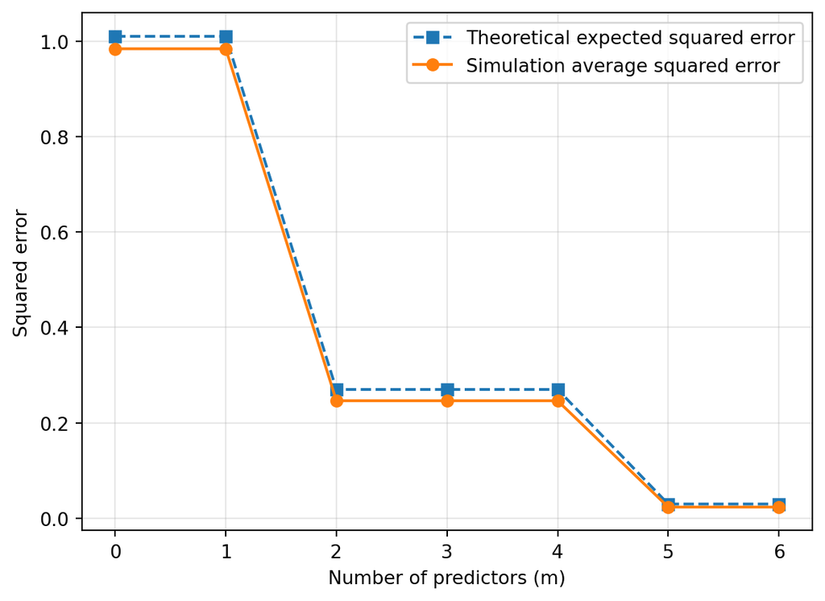

```
Smallest m minimizing theoretical error: 5
```

```python
import matplotlib.pyplot as plt

rng = np.random.default_rng(43203)
n_runs = 200

X = np.column_stack((np.ones(n), X_all))
x0_with_intercept = np.concatenate(([1], x0))
mu = X_all @ beta

squared_errors = np.zeros((n_runs, p + 1))
for run in range(n_runs):
    y = mu + rng.normal(loc=0, scale=1, size=n)

    for m in m_values:
        X_m = X[:, :m + 1]
        beta_hat = np.linalg.lstsq(X_m, y, rcond=None)[0]
        mu_hat = x0_with_intercept[:m + 1] @ beta_hat
        squared_errors[run, m] = (mu_hat - mu0) ** 2

avg_sq_err = squared_errors.mean(axis=0)

plt.plot(m_values, ese, "s--", label="Theoretical expected squared error")
plt.plot(m_values, avg_sq_err, "o-", label="Simulation average squared error")
plt.xlabel("Number of predictors (m)")
plt.ylabel("Squared error")
plt.xticks(m_values)
plt.legend()
plt.grid(alpha=0.3)
plt.show()

print("Smallest m minimizing theoretical error:", np.argmin(ese))
```

The smallest expected error is at 5.

3. All six regression coefficients are nonzero. Explain why only predictors 2 and 5 contribute directly to the mean response at $\mathbf x_0$. Contrast this target-specific error with the test MSE averaged over all rows of $\mathbf X_{\mathrm{all}}$ in Question 1.

Because the correspond values in x are 0s except for predictors 2 and 5. The MSE will averages prediction errors over all instances of X with every predictors can have nonzero values, but the target prerdictor only consider predictors with correspond x is non-zero. Prediction error measures error for the true mean at one point, while MSE measures test error for noisy responses across all design points.

## Question 3: The optimism correction

Choose one candidate model before observing the response. Let $p$ be its number of predictors and let $\mathbf X\in\mathbb R^{n\times(p+1)}$ be its full-rank design matrix, including the intercept. The model has $p+1$ fitted coefficients. Let

$$\mathbf H
=\mathbf X
(\mathbf X^{\mathsf T}\mathbf X)^{-1}
\mathbf X^{\mathsf T}$$

be its hat matrix. Suppose

$$\mathbf y=\boldsymbol\mu+\boldsymbol\epsilon,
\qquad
\mathbf y^*=\boldsymbol\mu+\boldsymbol\epsilon^*,$$

Conditional on the fixed design $\mathbf X$, the two error vectors are independent, have mean zero, and have covariance matrix $\sigma^2\mathbf I_n$. Define

$$\operatorname{MSE}_{\mathrm{train}}
=
\frac{1}{n}
\left\lVert
\mathbf y-\mathbf H\mathbf y
\right\rVert_2^2,
\qquad
\operatorname{MSE}_{\mathrm{test}}
=
\frac{1}{n}
\left\lVert
\mathbf y^*-\mathbf H\mathbf y
\right\rVert_2^2.$$

The conditional bias vector of the fitted mean is

$$E(\mathbf H\mathbf y\mid\mathbf X)-\boldsymbol\mu
=
-(\mathbf I_n-\mathbf H)\boldsymbol\mu.$$

Let $B^2$ denote the **total squared approximation bias**:

$$B^2
=\left\lVert
(\mathbf I_n-\mathbf H)\boldsymbol\mu
\right\rVert_2^2.$$

Thus, $B^2/n$ is the mean squared approximation bias.

You may use

$$\mathbf H^{\mathsf T}=\mathbf H,
\qquad
\mathbf H^2=\mathbf H,
\qquad
\operatorname{tr}(\mathbf H)=p+1.$$

For any fixed matrix $\mathbf A$, you may also use

$$E\!\left(
\boldsymbol\epsilon^{\mathsf T}
\mathbf A
\boldsymbol\epsilon
\mid \mathbf X
\right)
=\sigma^2\operatorname{tr}(\mathbf A).$$

1. Derive

$$E(\operatorname{MSE}_{\mathrm{train}}\mid\mathbf X)
=\frac{B^2}{n}
+\sigma^2\left(1-\frac{p+1}{n}\right),$$

and

$$E(\operatorname{MSE}_{\mathrm{test}}\mid\mathbf X)
=\frac{B^2}{n}
+\sigma^2\left(1+\frac{p+1}{n}\right).$$

$$\begin{aligned}
\operatorname{MSE}_{\mathrm{train}}
&=\frac{1}{n}\left\lVert \mathbf y-\mathbf H\mathbf y\right\rVert_2^2 \\
&=\frac{1}{n}\left\lVert (\mathbf I_n-\mathbf H)\mathbf y\right\rVert_2^2 \\
&=\frac{1}{n}\left\lVert (\mathbf I_n-\mathbf H)(\boldsymbol\mu+\boldsymbol\epsilon)\right\rVert_2^2 \\
&=\frac{1}{n}\left\lVert (\mathbf I_n-\mathbf H)\boldsymbol\mu+(\mathbf I_n-\mathbf H)\boldsymbol\epsilon\right\rVert_2^2 \\
&=\frac{1}{n}\left(
\boldsymbol\mu^{\mathsf T}(\mathbf I_n-\mathbf H)^{\mathsf T}(\mathbf I_n-\mathbf H)\boldsymbol\mu
+2\boldsymbol\mu^{\mathsf T}(\mathbf I_n-\mathbf H)^{\mathsf T}(\mathbf I_n-\mathbf H)\boldsymbol\epsilon
+\boldsymbol\epsilon^{\mathsf T}(\mathbf I_n-\mathbf H)^{\mathsf T}(\mathbf I_n-\mathbf H)\boldsymbol\epsilon
\right) \\
&=\frac{1}{n}\left(
B^2
+2\boldsymbol\mu^{\mathsf T}(\mathbf I_n-\mathbf H)\boldsymbol\epsilon
+\boldsymbol\epsilon^{\mathsf T}(\mathbf I_n-\mathbf H)^{\mathsf T}(\mathbf I_n-\mathbf H)\boldsymbol\epsilon
\right).
\end{aligned}$$

$$\begin{aligned}
E(\operatorname{MSE}_{\mathrm{train}}\mid\mathbf X)
&=E\!\left[
\frac{1}{n}\left(
B^2
+2\boldsymbol\mu^{\mathsf T}(\mathbf I_n-\mathbf H)\boldsymbol\epsilon
+\boldsymbol\epsilon^{\mathsf T}(\mathbf I_n-\mathbf H)^{\mathsf T}(\mathbf I_n-\mathbf H)\boldsymbol\epsilon
\right)
\middle|\mathbf X
\right] \\
&=\frac{B^2}{n}+\frac{\sigma^2\operatorname{tr}(\mathbf I_n-\mathbf H)}{n} \\
&=\frac{B^2}{n}+\frac{\sigma^2\{\operatorname{tr}(\mathbf I_n)-\operatorname{tr}(\mathbf H)\}}{n} \\
&=\frac{B^2}{n}+\frac{\sigma^2\{n-(p+1)\}}{n} \\
&=\frac{B^2}{n}+\sigma^2\left(1-\frac{p+1}{n}\right).
\end{aligned}$$

$$\begin{aligned}
\operatorname{MSE}_{\mathrm{test}}
&=\frac{1}{n}\left\lVert \mathbf y^*-\mathbf H\mathbf y\right\rVert_2^2 \\
&=\frac{1}{n}\left\lVert
\boldsymbol\mu+\boldsymbol\epsilon^*-\mathbf H(\boldsymbol\mu+\boldsymbol\epsilon)
\right\rVert_2^2 \\
&=\frac{1}{n}\left\lVert
(\mathbf I_n-\mathbf H)\boldsymbol\mu+\boldsymbol\epsilon^*-\mathbf H\boldsymbol\epsilon
\right\rVert_2^2 \\
&=\frac{1}{n}\left(
\left\lVert(\mathbf I_n-\mathbf H)\boldsymbol\mu\right\rVert_2^2
+(\boldsymbol\epsilon^*)^{\mathsf T}\boldsymbol\epsilon^*
+(\mathbf H\boldsymbol\epsilon)^{\mathsf T}\mathbf H\boldsymbol\epsilon
+2\boldsymbol\mu^{\mathsf T}(\mathbf I_n-\mathbf H)\boldsymbol\epsilon^*
-2\boldsymbol\mu^{\mathsf T}(\mathbf I_n-\mathbf H)\mathbf H\boldsymbol\epsilon
-2(\boldsymbol\epsilon^*)^{\mathsf T}\mathbf H\boldsymbol\epsilon
\right).
\end{aligned}$$

$$\begin{aligned}
E(\operatorname{MSE}_{\mathrm{test}}\mid\mathbf X)
&=E\!\left[
\frac{1}{n}\left(
\left\lVert(\mathbf I_n-\mathbf H)\boldsymbol\mu\right\rVert_2^2
+(\boldsymbol\epsilon^*)^{\mathsf T}\boldsymbol\epsilon^*
+(\mathbf H\boldsymbol\epsilon)^{\mathsf T}\mathbf H\boldsymbol\epsilon
\right)
\middle|\mathbf X
\right] \\
&=\frac{B^2}{n}
+\frac{1}{n}E\!\left[
(\boldsymbol\epsilon^*)^{\mathsf T}\mathbf I_n\boldsymbol\epsilon^*
+\boldsymbol\epsilon^{\mathsf T}\mathbf H^{\mathsf T}\mathbf H\boldsymbol\epsilon
\middle|\mathbf X
\right] \\
&=\frac{B^2}{n}+\frac{\sigma^2n+\sigma^2(p+1)}{n} \\
&=\frac{B^2}{n}+\sigma^2\left(1+\frac{p+1}{n}\right).
\end{aligned}$$

2. Deduce the expected optimism, defined as $E(\operatorname{MSE}_{\mathrm{test}}-\operatorname{MSE}_{\mathrm{train}}\mid\mathbf X)$. For

$$n=120,
\qquad
p=4,
\qquad
\frac{B^2}{n}=0.04,
\qquad
\sigma^2=1,$$

calculate the expected training MSE, expected test MSE, and their difference. Explain why the ordering need not hold for every realized pair of responses.

The expect value for train MSE is 1.00, and the expect value for test MSE is 1.08. The difference is 0.083. Because the random noise, train MSE is not always smaller than test MSE.

3. Continue with $n=120$ and $p=4$. Suppose the candidate model has residual sum of squares $\operatorname{RSS}=116.4$, and suppose a common estimate of the error variance is $\widehat\sigma^2=0.96$.

Calculate

$$\widehat{\operatorname{MSE}}_{\mathrm{test}}
=\frac{
\operatorname{RSS}+2(p+1)\widehat\sigma^2
}{n},$$

and

$$C_p
=\frac{\operatorname{RSS}}{\widehat\sigma^2}
-n+2(p+1).$$

Show how these two quantities are related, and explain why minimizing $C_p$ is equivalent to minimizing the corrected test MSE when $n$ and $\widehat\sigma^2$ are common to all candidate models.

$$C_p
=\frac{n\cdot\widehat{\operatorname{MSE}}_{\mathrm{test}}}{\widehat\sigma^2}
-n.$$

When n and $\widehat\sigma^2$ is unchanged, the change in $C_p$ is in the same direction as $\widehat{\operatorname{MSE}}_{\mathrm{test}}$.

## Question 4: Comparing Mallows’ $C_p$, AIC, and BIC

Use `data/diabetes.csv`, with `y` as the response. Use rows 1 through 370 as the training data, and let $n=370$ denote the training sample size. Do not use rows 371 through 442 in this question. Fit the following ordinary least-squares models, each with an intercept.

| Model | Predictors | $p$ |
| --- | --- | --- |
| Model A | `bmi`, `bp`, `s5`, `sex`, `s1`, `s2`, `s4` | 7 |
| Model B | all predictors in Model A, followed by `s6` | 8 |
| Full reference | all ten predictors | 10 |

Here $p$ counts predictors, so each model has $p+1$ fitted coefficients including the intercept. Estimate one common noise variance from the full reference model, using $p=10$:

$$\widehat\sigma^2
=\frac{\operatorname{RSS}_{\mathrm{full}}}{n-(p+1)}.$$

For Models A and B, calculate

$$C_p
=\frac{\operatorname{RSS}}{\widehat\sigma^2}
-n+2(p+1),$$

$$\operatorname{AIC}^{\mathrm{red}}
=n\log\left(\frac{\operatorname{RSS}}{n}\right)+2(p+1),$$

and

$$\operatorname{BIC}^{\mathrm{red}}
=n\log\left(\frac{\operatorname{RSS}}{n}\right)
+(p+1)\log(n).$$

The reduced AIC and BIC omit constants shared by the two candidate models. Smaller values are preferred within each criterion.

1. Fit the three models. Report $p$, RSS, the residual degrees of freedom of the full model, and $\widehat\sigma^2$.

**Show the starter code**

```python
import pandas as pd
data = pd.read_csv("data/diabetes.csv")
n = 370

y = data["y"].iloc[:370]
X_model1 = np.column_stack((np.ones(n), data[["bmi", "bp", "s5", "sex", "s1", "s2", "s4"]].iloc[:370]))
model1 = np.linalg.lstsq(X_model1, y, rcond=None)
X_model2 = np.column_stack((np.ones(n), data[["bmi", "bp", "s5", "sex", "s1", "s2", "s4", "s6"]].iloc[:370]))
model2 = np.linalg.lstsq(X_model2, y, rcond=None)
X_model3 = np.column_stack((np.ones(n), data.iloc[:370].drop(columns=["y"])))
model3 = np.linalg.lstsq(X_model3, y, rcond=None)

results = pd.DataFrame({
    "Model": ["Model A", "Model B", "Full reference"],
    "p": [
        int(len(model1[0]) - 1),
        int(len(model2[0]) - 1),
        int(len(model3[0]) - 1)
    ],
    "RSS": [
        model1[1].item(),
        model2[1].item(),
        model3[1].item()
    ]
})
results.round(4)
print(results)
df_residual = n - len(model3[0])
print("the residual degrees of freedom of the full model: ", df_residual)
sigmasq_hat = model3[1].item() / (n - len(model3[0]))
print("sigma_sq_hat: ", sigmasq_hat)
```

```
            Model   p           RSS
0         Model A   7  1.098909e+06
1         Model B   8  1.089717e+06
2  Full reference  10  1.089452e+06
the residual degrees of freedom of the full model:  359
sigma_sq_hat:  3034.684460220172
```

2. Calculate $C_p$, reduced AIC, and reduced BIC for Models A and B. State which model each criterion selects. Do not compare numerical values across different criteria.

**Show the starter code**

```python
rss_1 = model1[1].item()
p_1 = int(len(model1[0]) - 1)
rss_2 = model2[1].item()
p_2 = int(len(model2[0]) - 1)

cp_1 = rss_1 / sigmasq_hat - n + 2 * (p_1 + 1)
cp_2 = rss_2 / sigmasq_hat - n + 2 * (p_2 + 1)
print("Cp for model A: ", cp_1)
print("Cp for model B: ", cp_2)

aic_1 = n * np.log(rss_1 / n) + 2 * (p_1 + 1)
aic_2 = n * np.log(rss_2 / n) + 2 * (p_2 + 1)
print("AIC for model A: ", aic_1)
print("AIC for model B: ", aic_2)

bic_1 = n * np.log(rss_1 / n) + (p_1 + 1) * np.log(n)
bic_2 = n * np.log(rss_2 / n) + (p_2 + 1) * np.log(n)
print("BIC for model A: ", bic_1)
print("BIC for model B: ", bic_2)
```

```
Cp for model A:  8.116252959673204
Cp for model B:  7.087434322792774
AIC for model A:  2974.6402598107534
AIC for model B:  2973.5324845623886
BIC for model A:  3005.9482838558597
BIC for model B:  3008.754011613133
```

According Cp and AIC, model B is preferred. According to BIC, model A is preferred

3. Compare the improvement in fit from adding `s6` with the one-parameter penalty under each criterion. Use this comparison to explain any disagreement. Why does selecting a model not establish that it is the true data-generating model?

Only BIC show that adding s6 do not have improvement. BIC has a larger penalty on penalizing the number of predictors and under BIC the extra penalty outweights the improvement when adding s6. Therefore, in BIC the model B does not have a better preformance. Because the selection depends on the criterion.

## Question 5: Validation and final test data

Use rows 1 through 370 of `diabetes.csv` as the training data and rows 371 through 442 as the final test data. Consider eleven nested candidate models. For $m=0,1,\ldots,10$, the model with $m$ predictors contains an intercept and the first $m$ predictors in this order:

`age`, `sex`, `bmi`, `bp`, `s1`, `s2`, `s3`, `s4`, `s5`, `s6`.

An analyst proposes the following procedure:

1. Fit all eleven candidate models using the training data.
2. Calculate the MSE of each model on the final test data.
3. Select the model with the smallest test MSE.
4. Report that minimum as the final estimate of prediction error.

The analyst argues that the procedure is valid because the final test data were not used to estimate the regression coefficients.

1. Identify the first step that misuses the final test data. Explain why the minimum of eleven test MSE values is generally too favorable as an estimate of the selected procedure’s future prediction error.

It is the step 2. Becauses the selected procedure involves random variation, which may leads to the extreme small MSE.

2. Rewrite the analysis using five-fold cross-validation within the training data. State how the predictor count is selected, what is refitted, and when the final test data may be used.

The whole training observation are splitted into five folds. For one m, 4 folds are selected for training and the rest used as validation. Repete this model fitting on different validation fold for 5 times and calculate the MSE each time. The cross-validation score at m will be the average of the 5 MSE. The m with smallest cross-validation score is selected, and model with m predictors is fitted using training observation. Then use this model to predict the observations in test data.

3. Suppose the analyst has already examined all eleven test MSE values. What can still be reported transparently, and what additional data would be needed for a new final evaluation?

The final model and the suitable predictor count could be reported transparently. New final evaluation need more data from target population.

## Reference

James, Witten, Hastie, Tibshirani, and Taylor, [*An Introduction to Statistical Learning*](https://www.statlearning.com/), Chapters 3, 5, and 6.